# F Test Power Simulation

Jingyang(Judy) Zhang

10/25/2021

```r
library(tidyverse)
library(ggpubr)
```

# Intro

In this simulation, we will try different combinations of values of the three parameters:

$n_0$: control group sample size;

$n_1$: treatment group sample size;

$\phi = \frac{\sigma_1^2}{\sigma_0^2}$: ratio of population variances of the treatment group over the control group.

The power can be calculated by:

$Pr(F > \phi F_{n_1 -1, n_0 -1})$

where $F = \frac{s_1^2}{s_0^2} = \frac{MSE_1}{MSE_0}$

# Functions

Function: cal_power() calculates power for a two-sided F-test for equality of two variances.

Arguments: var1_popl: population variance for the treatment group. var0_popl: population variance for the control group. var1: sample variance for the treatment group. var0 sample variance for the control group. n1: sample size for the treatment group. n0: sample size for the control group. alpha: significance level for the F-test of equality of two population variances.

Return: power: calculated power for the F-test for equality of two variances.

```r
cal_power <- function(var1_popl, var0_popl, var1, var0, n1, n0, alpha){



  F_stat <- var1/var0


  phi <- var1_popl/var0_popl

  F_crit_low <- qf(alpha/2, n1-1, n0-1, lower.tail = TRUE, log.p = FALSE)

  F_crit_up <- qf(1 - alpha/2, n1-1, n0-1, lower.tail = TRUE, log.p = FALSE)

  p_low <- pf(phi*F_crit_low, n1-1, n0-1, lower.tail = TRUE, log.p = FALSE)

  p_up <- pf(phi*F_crit_up, n1-1, n0-1, lower.tail = FALSE, log.p = FALSE)

  power <- p_low + p_up

  return(power)


}
```

Test cal_power() Function

Assume $X\sim N(\mu_0, \sigma_0^2)$ is the control group population and $Y\sim N(\mu_1, \sigma_1^2)$ is the treatment group population.

We will be randomly drawing a sample of size n0 from the control group population and a sample of size n1 from the treatment group population.

$n_0 = n_1 = 30$

```r
var1_popl <- 180
var0_popl <- 175
mu1 <- 0
mu0 <- 0


n1 <- 30
n0 <- 30


trt_sample <- rnorm(n1, mean = mu1, sd = sqrt(var1_popl))
ctrl_sample <- rnorm(n0, mean = mu0, sd = sqrt(var0_popl))

var1 <- (sd(trt_sample))^2
var0 <- (sd(ctrl_sample))^2

cal_power(var1_popl, var0_popl, var1, var0, n1, n0, 0.05)
```

```
## [1] 0.05061701
```

Function: simulate_power()

Arguments:

var1popl_list: a vector containing a list of population variances for different treatment groups.

var0popl_list: a vector containing a list of population variances for different control groups.

var1_list: a vector containing a list of sample variances for different treatment group samples.

var0_list: a vector containing a list of sample variances for different control group samples.

n1_list: a vector containing a list of sample sizes for different treatment group samples.

n0_list: a vector containing a list of sample sizes for different treatment group samples.

alpha_list: a vector containing a list of significance levels.

Return: result_table: a tibble containing parameters and corresponding power of the F test.

```r
simulate_power <- function(var1popl_list, var0popl_list, var1_list, var0_list, n1_list, n0_list, alpha_list){

  power <- c()

  for(i in 1:length(var1popl_list)){

    power[i] <- cal_power(var1popl_list[i], var0popl_list[i], var1_list[i], var0_list[i], n1_list[i], n0_list[i], alpha_list[i])

  }

  # Result table will provide three parameters and corresponding power: phi, n1, n0, and power

  result_table <- tibble(phi = var1popl_list/var0popl_list, n1 = n1_list, n0 = n0_list, power = power)

  return(result_table)


}
```

Test Data:

```r
var1popl_list <- c(10, 20)
var0popl_list <- c(15, 21)
mu1 <- 0
mu0 <- 0


n1_list <- c(30, 30)
n0_list <- c(30, 30)


var1_list <- c()
var0_list <- c()

for(i in 1:length(var1popl_list)){

  trt <- rnorm(n1_list[i], mean = mu1, sd = sqrt(var1popl_list[i]))
  var1_list[i] <- (sd(trt))^2
  ctrl <- rnorm(n0_list[i], mean = mu0, sd = sqrt(var0popl_list[i]))
  var0_list[i] <- (sd(ctrl))^2

}

alpha_list <- c(0.05, 0.05)


result_table <- simulate_power(var1popl_list, var0popl_list, var1_list, var0_list, n1_list, n0_list, alpha_list)
```

# Simulations

## Same Sample Size with Different Phi

```r
var1popl_list <- seq(10, 1, by = - 0.01)
var0popl_list <- rep(10, length(var1popl_list))
mu1 <- 0
mu0 <- 0


n1_list <- rep(30, length(var1popl_list))
n0_list <- rep(30, length(var1popl_list))


var1_list <- c()
var0_list <- c()

for(i in 1:length(var1popl_list)){

  trt <- rnorm(n1_list[i], mean = mu1, sd = sqrt(var1popl_list[i]))

  var1_list[i] <- (sd(trt))^2

  ctrl <- rnorm(n0_list[i], mean = mu0, sd = sqrt(var0popl_list[i]))

  var0_list[i] <- (sd(ctrl))^2

}

alpha_list <- rep(0.05, length(var1popl_list))


result_table_phi <- simulate_power(var1popl_list, var0popl_list, var1_list, var0_list, n1_list, n0_list, alpha_list)
```

Plot phi v.s. power

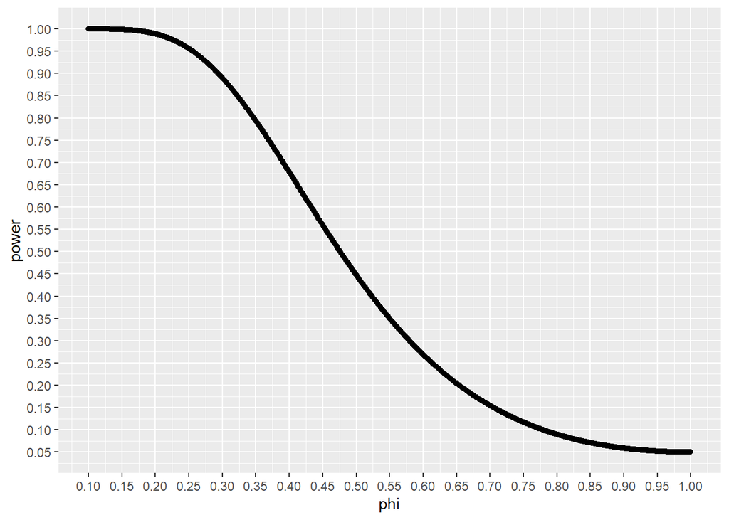

```r
ggplot(result_table_phi, aes(x = phi, y = power)) +
  geom_point() +
  scale_x_continuous(breaks = seq(0, 1, by = 0.05)) +
  scale_y_continuous(breaks = seq(0, 1, by = 0.05))
```

```r
  theme(axis.text.x = element_text(angle = 295, vjust = 0.5, hjust=1))
```

[output not shown]

1. As $\phi\rightarrow 1$, power declines.
2. As $\phi\rightarrow 1$, the rate of decline of the power increases and then decreases.
3. As $\phi\rightarrow 1$, the power decreases faster for $\phi\in [0.30, 0.60]$ than for $\phi\in (0, 0.30)\cup(0.6, 1)$.

## Different Sample Sizes with the Same Phi

```r
n1_list <- seq(10, 100, by = 1)
n0_list <- rep(100, length(n1_list))

var1popl_list <- rep(5, length(n1_list))
var0popl_list <- rep(10, length(n1_list))
mu1 <- 0
mu0 <- 0





var1_list <- c()
var0_list <- c()

for(i in 1:length(var1popl_list)){

  trt <- rnorm(n1_list[i], mean = mu1, sd = sqrt(var1popl_list[i]))

  var1_list[i] <- (sd(trt))^2

  ctrl <- rnorm(n0_list[i], mean = mu0, sd = sqrt(var0popl_list[i]))

  var0_list[i] <- (sd(ctrl))^2

}

alpha_list <- rep(0.05, length(n1_list))


result_table_size <- simulate_power(var1popl_list, var0popl_list, var1_list, var0_list, n1_list, n0_list, alpha_list)
```

Plot sample size v.s. power

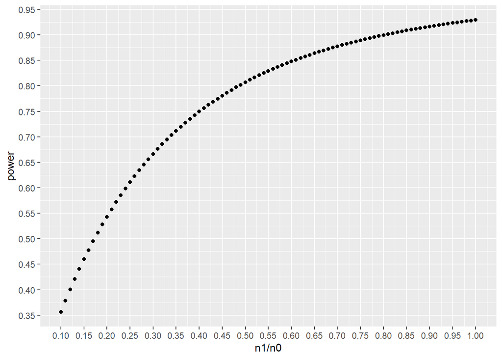

```r
ggplot(result_table_size, aes(x = n1/n0, y = power)) +
  geom_point() +
  scale_x_continuous(breaks = seq(0, 1, by = 0.05)) +
  scale_y_continuous(breaks = seq(0, 1, by = 0.05))
```

```r
  theme(axis.text.x = element_text(angle = 295, vjust = 0.5, hjust=1))
```

[output not shown]

1. As $\frac{n_1}{n_0}\rightarrow 1$, power increases.
2. As $\frac{n_1}{n_0}\rightarrow 1$, the rate of increase of power decreases.

## Sample Size, Phi and Power

### $\phi = 0.95$

```r
n1_list <- seq(10, 200, by = 1)
n0_list <- n1_list

var1popl_list <- rep(9.5, length(n1_list))
var0popl_list <- rep(10, length(n1_list))
mu1 <- 0
mu0 <- 0





var1_list <- c()
var0_list <- c()

for(i in 1:length(var1popl_list)){

  trt <- rnorm(n1_list[i], mean = mu1, sd = sqrt(var1popl_list[i]))

  var1_list[i] <- (sd(trt))^2

  ctrl <- rnorm(n0_list[i], mean = mu0, sd = sqrt(var0popl_list[i]))

  var0_list[i] <- (sd(ctrl))^2

}

alpha_list <- rep(0.05, length(n1_list))


result_table_phi95 <- simulate_power(var1popl_list, var0popl_list, var1_list, var0_list, n1_list, n0_list, alpha_list)
```

Plot sample size v.s. power for $\phi = 0.95$

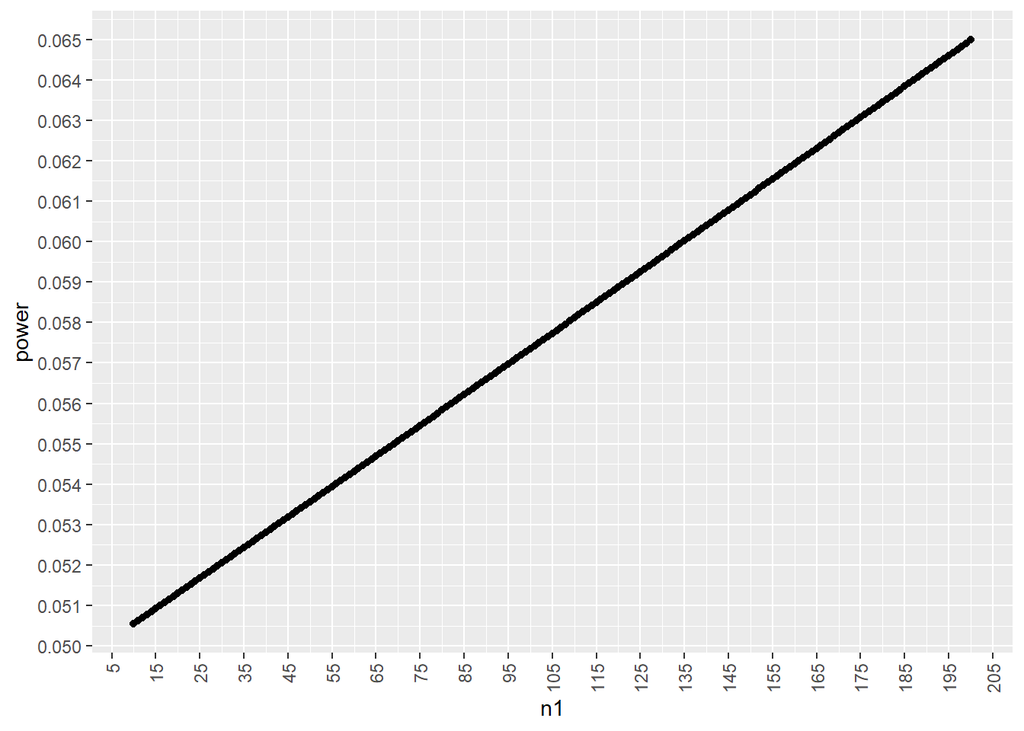

```r
phi95 <- ggplot(result_table_phi95, aes(x = n1, y = power)) +
  geom_point() +
  scale_x_continuous(breaks = seq(5, 210, by = 10)) +
  scale_y_continuous(breaks = seq(0, 1, by = 0.001)) +
  theme(axis.text.x = element_text(angle = 90, vjust = 0.5, hjust=1))

phi95
```

### $\phi = 0.9$

```r
n1_list <- seq(10, 200, by = 1)
n0_list <- n1_list

var1popl_list <- rep(9, length(n1_list))
var0popl_list <- rep(10, length(n1_list))
mu1 <- 0
mu0 <- 0





var1_list <- c()
var0_list <- c()

for(i in 1:length(var1popl_list)){

  trt <- rnorm(n1_list[i], mean = mu1, sd = sqrt(var1popl_list[i]))

  var1_list[i] <- (sd(trt))^2

  ctrl <- rnorm(n0_list[i], mean = mu0, sd = sqrt(var0popl_list[i]))

  var0_list[i] <- (sd(ctrl))^2

}

alpha_list <- rep(0.05, length(n1_list))


result_table_phi90 <- simulate_power(var1popl_list, var0popl_list, var1_list, var0_list, n1_list, n0_list, alpha_list)
```

Plot sample size v.s. power for $\phi = 0.9$

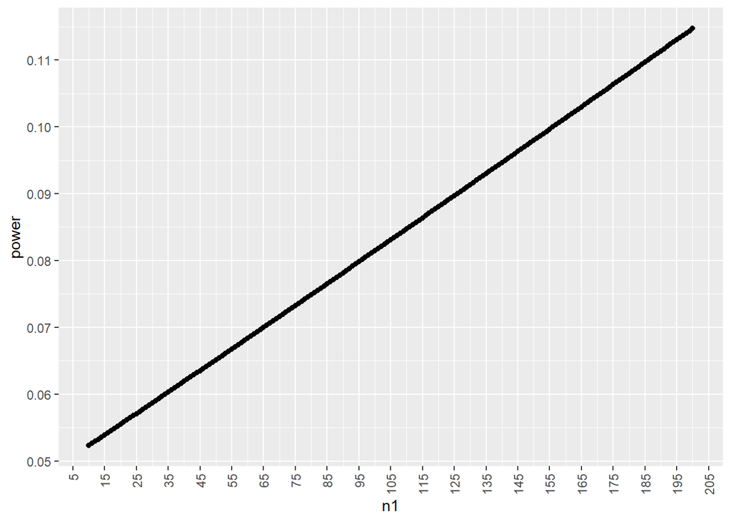

```r
phi90 <- ggplot(result_table_phi90, aes(x = n1, y = power)) +
  geom_point() +
  scale_x_continuous(breaks = seq(5,230, by = 10)) +
  scale_y_continuous(breaks = seq(0, 1, by = 0.01)) +
  theme(axis.text.x = element_text(angle = 90, vjust = 0.5, hjust=1))

phi90
```

### $\phi = 0.7$

```r
n1_list <- seq(10, 200, by = 1)
n0_list <- n1_list

var1popl_list <- rep(7, length(n1_list))
var0popl_list <- rep(10, length(n1_list))
mu1 <- 0
mu0 <- 0





var1_list <- c()
var0_list <- c()

for(i in 1:length(var1popl_list)){

  trt <- rnorm(n1_list[i], mean = mu1, sd = sqrt(var1popl_list[i]))

  var1_list[i] <- (sd(trt))^2

  ctrl <- rnorm(n0_list[i], mean = mu0, sd = sqrt(var0popl_list[i]))

  var0_list[i] <- (sd(ctrl))^2

}

alpha_list <- rep(0.05, length(n1_list))


result_table_phi70 <- simulate_power(var1popl_list, var0popl_list, var1_list, var0_list, n1_list, n0_list, alpha_list)
```

Plot sample size v.s. power for $\phi = 0.7$

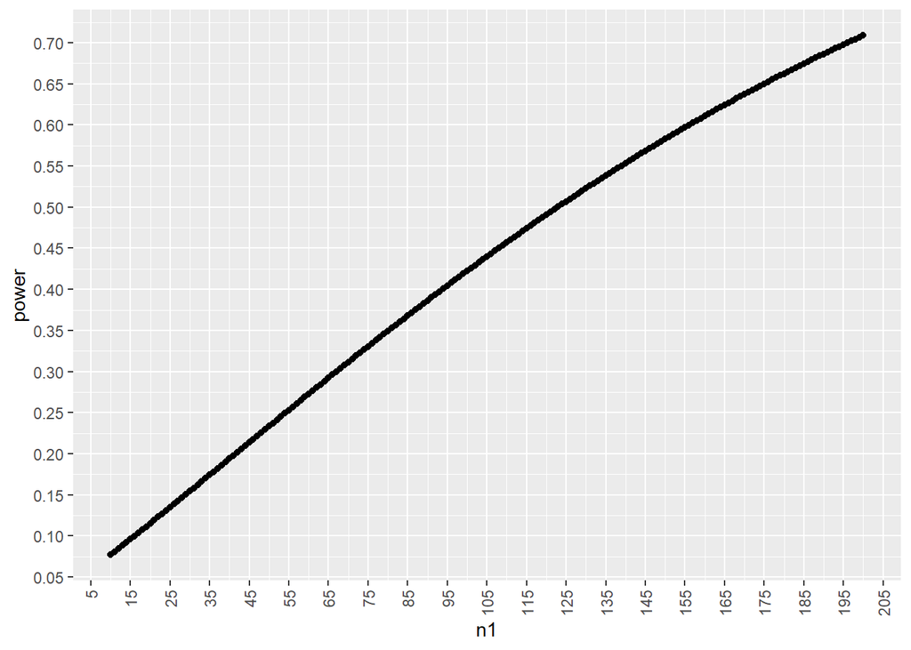

```r
phi70 <- ggplot(result_table_phi70, aes(x = n1, y = power)) +
  geom_point() +
  scale_x_continuous(breaks = seq(5, 210, by = 10)) +
  scale_y_continuous(breaks = seq(0, 1, by = 0.05)) +
  theme(axis.text.x = element_text(angle = 90, vjust = 0.5, hjust=1))

phi70
```

1. As $n_1 = n_0 = n\rightarrow 1$, power increases.
2. As $n_1 = n_0 = n\rightarrow 1$, the rate of increase of power decreases.

### $\phi = 0.5$

```r
n1_list <- seq(10, 200, by = 1)
n0_list <- n1_list

var1popl_list <- rep(5, length(n1_list))
var0popl_list <- rep(10, length(n1_list))
mu1 <- 0
mu0 <- 0





var1_list <- c()
var0_list <- c()

for(i in 1:length(var1popl_list)){

  trt <- rnorm(n1_list[i], mean = mu1, sd = sqrt(var1popl_list[i]))

  var1_list[i] <- (sd(trt))^2

  ctrl <- rnorm(n0_list[i], mean = mu0, sd = sqrt(var0popl_list[i]))

  var0_list[i] <- (sd(ctrl))^2

}

alpha_list <- rep(0.05, length(n1_list))


result_table_phi50 <- simulate_power(var1popl_list, var0popl_list, var1_list, var0_list, n1_list, n0_list, alpha_list)
```

Plot sample size v.s. power for $\phi = 0.5$

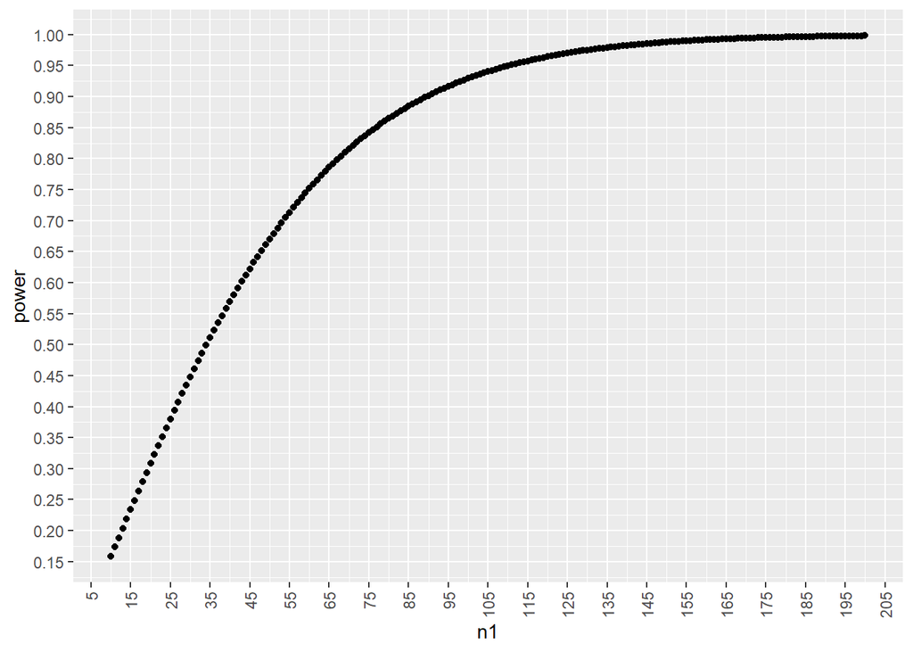

```r
phi50 <- ggplot(result_table_phi50, aes(x = n1, y = power)) +
  geom_point() +
  scale_x_continuous(breaks = seq(5, 210, by = 10)) +
  scale_y_continuous(breaks = seq(0, 1, by = 0.05)) +
  theme(axis.text.x = element_text(angle = 90, vjust = 0.5, hjust=1))

phi50
```

1. As $n_1 = n_0 = n\rightarrow 1$, power increases.
2. As $n_1 = n_0 = n\rightarrow 1$, the rate of increase of power decreases.

Compare

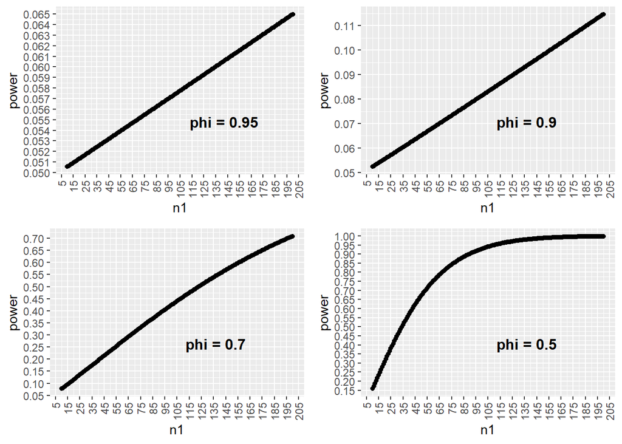

```r
ggarrange(phi95, phi90, phi70, phi50,
          labels = c("phi = 0.95", "phi = 0.9", "phi = 0.7", "phi = 0.5"),
          label.x = 0.5,
          label.y = 0.5,
          font.label = list(size = 12),
          ncol = 2, nrow = 2)
```

1. One obvious pattern is that for any given sample size n, the larger the $\phi$, the smaller the power.
2. For large value of $\phi$, the effect of increasing sample size n on increasing the power is about the same for small and large sample sizes.
3. For small value of $\phi$, there is a diminishing effect of increasing sample size n on increasing the power. That is, as sample size gets larger, the increase in power gets smaller.

In general, as $\phi$ decreases, the relationship between sample size n and power goes from a linear function to a concave function.